# DESeq Analysis of U2AF1, U2AF2, SF1

## 5.2 Heatmap DEGs of 305 SFs

*Create a rowAnnotation extract splicing genes according to as_anno (imported) file

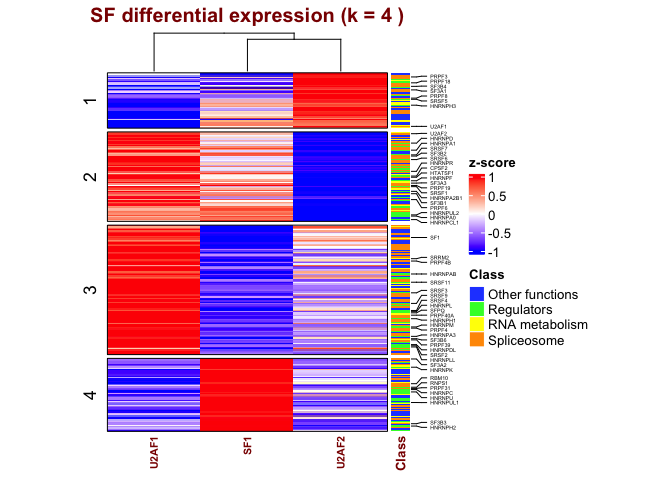

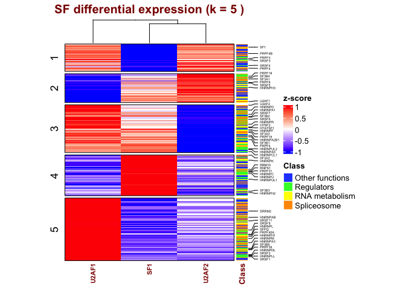

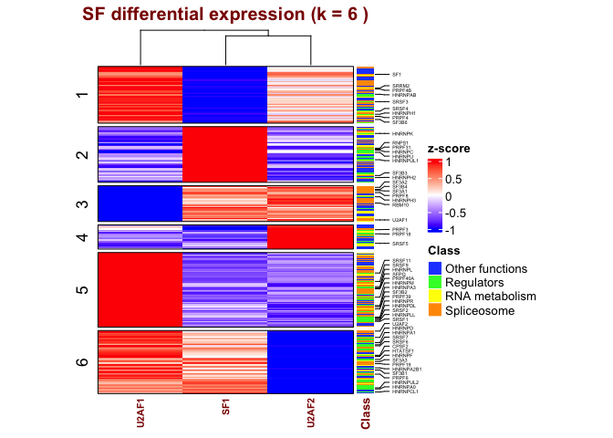

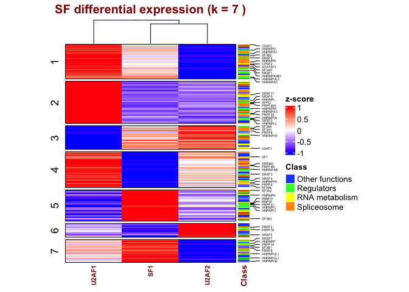

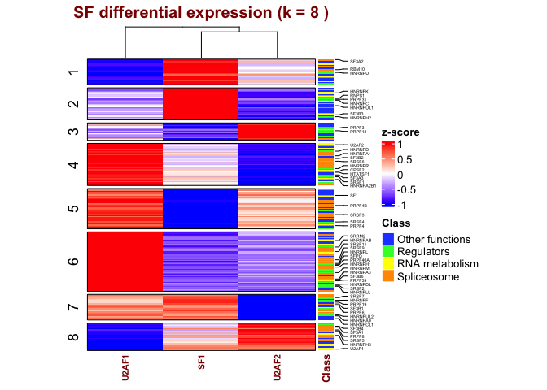

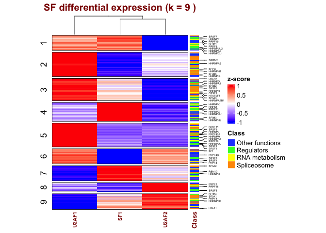

```r
SFcluster_list = list()
for (k in 4:9){
  ########################## Row clustering (genes)
  set.seed(123)

  # Try different kmean to see which kmean gives best cluster
  scaled_mat = t(scale(t(SF_hm_mat)))  # row-wise z-score scaling on a matrix (mean=0, sd=1)and transpose
  row_cluster = kmeans(scaled_mat, centers = k, nstart = 25)

  # assign result of kmeans to cluster list kk
  SFcluster_list[[paste0("k", k)]] = row_cluster

  # order of cluster labels
  row_sort = order(row_cluster$cluster)

  # Create matrix following row order
  splice_mat = scaled_mat[row_sort, ]

  # Create a mapping from gene symbol to class
  class_map = setNames(as_anno$class, as_anno$splice_SYMBOL)

  # Get class names with rownames
  class_genes = class_map[rownames(splice_mat)]
  class_genes = class_genes[!is.na(class_genes)] # Filter NA

  # Filter splice_mat to keep only genes with class
  splice_mat = splice_mat[names(class_genes), ]   # filter splice_mat rows to those genes

  ########################## Define mapping from detailed classes to broader categories and coloring
  class_merge_map = c(
  # All spliceosome-related grouped as one
  "U1 snRNP" = "Spliceosome",
  "U2 snRNP" = "Spliceosome",
  "U2 snRNP related" = "Spliceosome",
  "U4/U6 snRNP" = "Spliceosome",
  "U4/U6.U5 snRNP" = "Spliceosome",
  "U5 snRNP" = "Spliceosome",
  "A complex" = "Spliceosome",
  "B complex" = "Spliceosome",
  "C complex" = "Spliceosome",
  "PRP19 complex" = "Spliceosome",
  "Bact complex" = "Spliceosome",
  "SM proteins" = "Spliceosome",

  # All RNA-related functions together
  "RNA binding proteins" = "RNA metabolism",
  "RNA modifying" = "RNA metabolism",
  "RNA degradation" = "RNA metabolism",
  "RNA metylation" = "RNA metabolism",
  "RNA editing" = "RNA metabolism",

  # Splicing regulators grouped with mRNA processing
  "SR proteins" = "Regulators",
  "hnRNP" = "Regulators",
  "3´end" = "Regulators",
  "TREX" = "Regulators",
  "EJC / mRNP" = "Regulators",
  "CBC" = "Regulators",

  # Chromatin and enzymatic activities grouped as "Other functions"
  "SWI/SNF Complex Components" = "Other functions",
  "chromatin-related" = "Other functions",
  "Polycomb Group Genes" = "Other functions",
  "Histone transferases" = "Other functions",
  "Lysine transferases" = "Other functions",
  "helicase" = "Other functions",
  "protein kinase" = "Other functions",
  "LSm proteins" = "Other functions",
  "RES complex" = "Other functions",
  "Minor" = "Other functions",
  "Other SAPs" = "Other functions",
  "RISC" = "Other functions"
)

  # Ensure names match rownames of matrix_splice in order
  class_df = data.frame(
    gene = names(class_genes),
    class = class_genes, #   # Match class to heatmap rownames order
    stringsAsFactors = FALSE) %>%
    mutate(merged_class = class_merge_map[class],
    merged_class = ifelse(is.na(merged_class), "Others", merged_class))

  manual_colors = c(
  "Spliceosome" = "#FF9900FF",
  "RNA metabolism" = "yellow",
  "Regulators" = "#33FF33FF",
  "Other functions" = "#264EFFFF",
  "Others" = "black")

  # Generate colors
  merged_colors = manual_colors[sort(unique(class_df$merged_class))]
  names(merged_colors) = sort(unique(class_df$merged_class))

  class_colors = list(Class = merged_colors)

  ################## match row split with scaled_mat
  row_split = row_cluster$cluster
  names(row_split) = rownames(scaled_mat)
  row_split = row_split[rownames(splice_mat)]

  ########################## Build row annotation using merged class
  ha_row = rowAnnotation(
    Class = class_df$merged_class[match(rownames(splice_mat), class_df$gene)],
    width = unit(25, "mm"),
    col = class_colors,
    show_legend = TRUE,
    annotation_name_gp = gpar(fontsize = 10, fontface = "bold", col = "darkred"))

  ########################## Create mark annotation for GOI
  # Add GOI column that contains U2, SR, SF in the name of genes
  SF_anno = mutate(as_anno, GOI = case_when(
      grepl("U2AF2", splice_SYMBOL) ~ splice_SYMBOL,
      grepl("U2AF1", splice_SYMBOL) ~ splice_SYMBOL,
      grepl("SF", splice_SYMBOL) ~ splice_SYMBOL,
      grepl("SRSF", splice_SYMBOL) ~ splice_SYMBOL,
      grepl("PRPF", splice_SYMBOL) ~ splice_SYMBOL,
      grepl("RBM10", splice_SYMBOL) ~ splice_SYMBOL,
      grepl("HNRNP", splice_SYMBOL) ~ splice_SYMBOL,
      grepl("SRRM2", splice_SYMBOL) ~ splice_SYMBOL,
      grepl("SON1", splice_SYMBOL) ~ splice_SYMBOL,
      grepl("RNPS1", splice_SYMBOL) ~ splice_SYMBOL,
      TRUE ~ NA))

  # filter genes that is not within GOI
  SF_anno_GOI = SF_anno[!is.na(SF_anno$GOI), ]

  # match rownames of dds matrix to ensembl of my.genes df for annotation
  SF_index = match(SF_anno_GOI$splice_SYMBOL, rownames(splice_mat))
  # remove NA value row
  SF_index = SF_index[!is.na(SF_index)]

  # label with only GOI (splicing-involved genes)
  label = SF_anno_GOI$GOI

  hm_SFanno = rowAnnotation(foo = anno_mark(at = SF_index,
                                        labels = label,
                                        labels_gp = gpar(fontsize = 4,
                                                         font = 6), padding = unit(0.3, "mm")))

  ht = ComplexHeatmap::Heatmap(splice_mat,
      cluster_columns = TRUE,
      cluster_rows = FALSE,
      use_raster = TRUE,
      show_row_names = FALSE,
      row_names_gp = grid::gpar(fontsize = 5),
      col = colorRamp2(c(-1, 0, 1), c("blue", "white", "red")),
      column_title = paste("SF differential expression (k =",k,")"),
      column_title_gp = gpar(fontsize = 15, col = "darkred", fontface = "bold"),
      name = "z-score",
      row_split = row_split,
      border = TRUE,
      column_names_gp = grid::gpar(fontsize=8, col = "darkred", fontface = "bold"),
      heatmap_width = unit(10, "cm"),
      right_annotation = c(ha_row, hm_SFanno))

  print(ht)}
```

```r
#draw(ht, heatmap_legend_side = "right", annotation_legend_side = "right")
```

## 5.3 Heatmap DEGs of 305 SFs

*Create a rowAnnotation extract splicing genes according to as_anno (imported) file

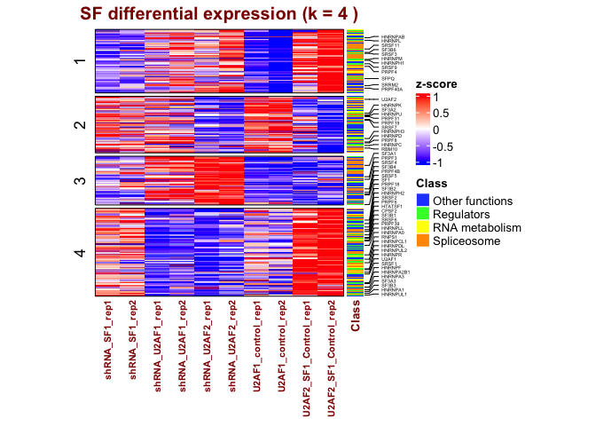

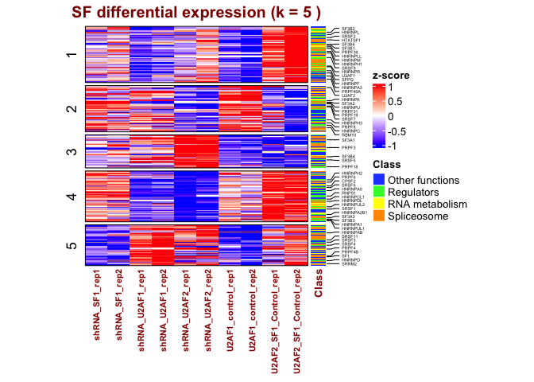

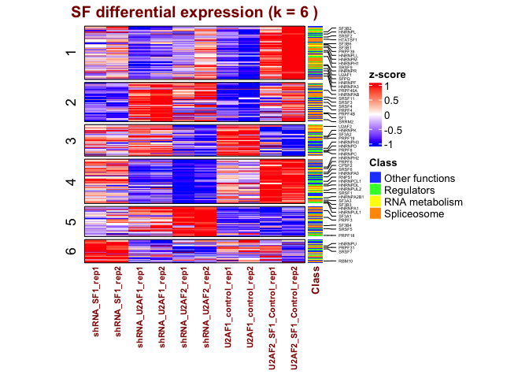

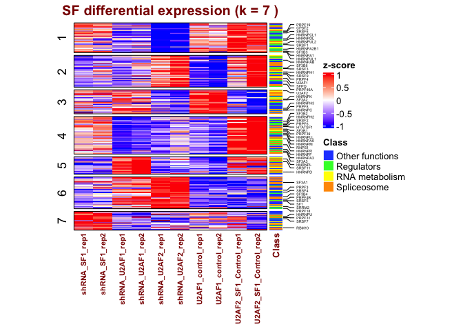

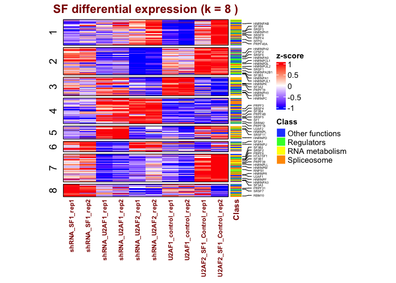

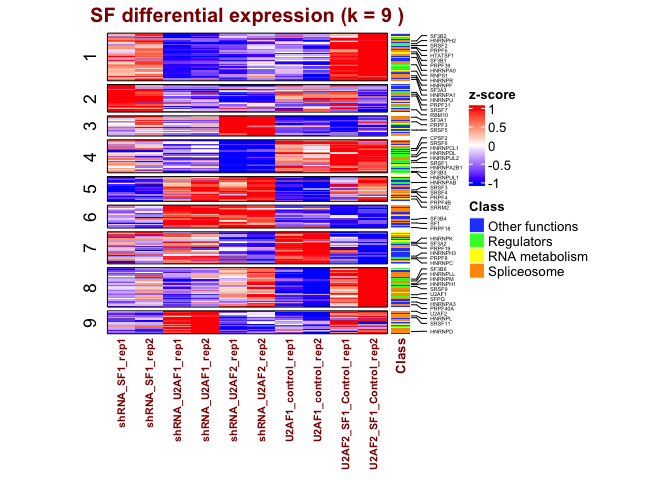

```r
matrix_nozero1 = matrix_nozero[rownames(matrix_nozero) %in% as_anno_genes,]
rownames(matrix_nozero1) = setNames(as_anno$splice_SYMBOL, as_anno$splice_ENSEMBL)[rownames(matrix_nozero1)]

SFcluster_list1 = list()
for (k in 4:9){
  ########################## Row clustering (genes)
  set.seed(123)

  # Try different kmean to see which kmean gives best cluster
  row_cluster1 = kmeans(matrix_nozero1, centers = k, nstart = 25)

  # assign result of kmeans to cluster list kk
  SFcluster_list1[[paste0("k", k)]] = row_cluster

  # order of cluster labels
  row_sort1 = order(row_cluster1$cluster)

  # Create matrix following row order
  splice_mat1 = matrix_nozero1[row_sort1, ]

  # Create a mapping from gene symbol to class
  class_map1 = setNames(as_anno$class, as_anno$splice_SYMBOL)

  # Get class names with rownames
  class_genes1 = class_map[rownames(splice_mat1)]
  class_genes1 = class_genes[!is.na(class_genes1)] # Filter NA

  # Filter splice_mat to keep only genes with class
  splice_mat1 = splice_mat1[rownames(splice_mat1) %in% names(class_genes1), ]   # filter splice_mat rows to those genes

  ########################## Define mapping from detailed classes to broader categories and coloring
  class_merge_map = c(
  # All spliceosome-related grouped as one
  "U1 snRNP" = "Spliceosome",
  "U2 snRNP" = "Spliceosome",
  "U2 snRNP related" = "Spliceosome",
  "U4/U6 snRNP" = "Spliceosome",
  "U4/U6.U5 snRNP" = "Spliceosome",
  "U5 snRNP" = "Spliceosome",
  "A complex" = "Spliceosome",
  "B complex" = "Spliceosome",
  "C complex" = "Spliceosome",
  "PRP19 complex" = "Spliceosome",
  "Bact complex" = "Spliceosome",
  "SM proteins" = "Spliceosome",

  # All RNA-related functions together
  "RNA binding proteins" = "RNA metabolism",
  "RNA modifying" = "RNA metabolism",
  "RNA degradation" = "RNA metabolism",
  "RNA metylation" = "RNA metabolism",
  "RNA editing" = "RNA metabolism",

  # Splicing regulators grouped with mRNA processing
  "SR proteins" = "Regulators",
  "hnRNP" = "Regulators",
  "3´end" = "Regulators",
  "TREX" = "Regulators",
  "EJC / mRNP" = "Regulators",
  "CBC" = "Regulators",

  # Chromatin and enzymatic activities grouped as "Other functions"
  "SWI/SNF Complex Components" = "Other functions",
  "chromatin-related" = "Other functions",
  "Polycomb Group Genes" = "Other functions",
  "Histone transferases" = "Other functions",
  "Lysine transferases" = "Other functions",
  "helicase" = "Other functions",
  "protein kinase" = "Other functions",
  "LSm proteins" = "Other functions",
  "RES complex" = "Other functions",
  "Minor" = "Other functions",
  "Other SAPs" = "Other functions",
  "RISC" = "Other functions"
)

  # Ensure names match rownames of matrix_splice in order
  class_df1 = data.frame(
    gene = names(class_genes1),
    class = class_genes1, #   # Match class to heatmap rownames order
    stringsAsFactors = FALSE) %>%
    mutate(merged_class = class_merge_map[class],
    merged_class = ifelse(is.na(merged_class), "Others", merged_class))

  manual_colors = c(
  "Spliceosome" = "#FF9900FF",
  "RNA metabolism" = "yellow",
  "Regulators" = "#33FF33FF",
  "Other functions" = "#264EFFFF",
  "Others" = "black")

  # Generate colors
  merged_colors = manual_colors[sort(unique(class_df$merged_class))]
  names(merged_colors) = sort(unique(class_df$merged_class))

  class_colors = list(Class = merged_colors)

  ########################## get row split match with row in matrix
  row_split = row_cluster1$cluster[row_sort1]
  row_split = row_split[rownames(splice_mat1)]

  ########################## Build row annotation using merged class
  ha_row1 = rowAnnotation(
    Class = class_df1$merged_class[match(rownames(splice_mat1), class_df$gene)],
    width = unit(25, "mm"),
    col = class_colors,
    show_legend = TRUE,
    annotation_name_gp = gpar(fontsize = 10, fontface = "bold", col = "darkred"))

  ########################## Create mark annotation for GOI
  # Add GOI column that contains U2, SR, SF in the name of genes
  SF_anno = mutate(as_anno, GOI = case_when(
      grepl("U2AF2", splice_SYMBOL) ~ splice_SYMBOL,
      grepl("U2AF1", splice_SYMBOL) ~ splice_SYMBOL,
      grepl("SF", splice_SYMBOL) ~ splice_SYMBOL,
      grepl("SRSF", splice_SYMBOL) ~ splice_SYMBOL,
      grepl("PRPF", splice_SYMBOL) ~ splice_SYMBOL,
      grepl("RBM10", splice_SYMBOL) ~ splice_SYMBOL,
      grepl("HNRNP", splice_SYMBOL) ~ splice_SYMBOL,
      grepl("SRRM2", splice_SYMBOL) ~ splice_SYMBOL,
      grepl("SON1", splice_SYMBOL) ~ splice_SYMBOL,
      grepl("RNPS1", splice_SYMBOL) ~ splice_SYMBOL,
      TRUE ~ NA)) # Assign all GOI related to splicing using grepl()

  # filter genes that is not within GOI
  SF_anno_GOI = SF_anno[!is.na(SF_anno$GOI), ]

  # match rownames of dds matrix to ensembl of my.genes df for annotation
  SF_index1 = match(SF_anno_GOI$splice_SYMBOL, rownames(splice_mat1))
  # remove NA value row
  SF_index1 = SF_index1[!is.na(SF_index1)]

  # label with only GOI (splicing-involved genes)
  label = SF_anno_GOI$GOI

  hm_SFanno1 = rowAnnotation(foo = anno_mark(at = SF_index1,
                                        labels = label,
                                        labels_gp = gpar(fontsize = 4,
                                                         font = 6), padding = unit(0.3, "mm")))


  ht1 = ComplexHeatmap::Heatmap(splice_mat1,
      cluster_columns = FALSE,
      cluster_rows = FALSE,
      use_raster = TRUE,
      show_row_names = FALSE,
      row_names_gp = grid::gpar(fontsize = 5),
      col = colorRamp2(c(-1, 0, 1), c("blue", "white", "red")),
      column_title = paste("SF differential expression (k =",k,")"),
      column_title_gp = gpar(fontsize = 15, col = "darkred", fontface = "bold"),
      name = "z-score",
      row_split = row_split,
      border = TRUE,
      column_names_gp = grid::gpar(fontsize=8, col = "darkred", fontface = "bold"),
      heatmap_width = unit(10, "cm"),
      right_annotation = c(ha_row1, hm_SFanno1))

  print(ht1)}
```

```r
#draw(ht, heatmap_legend_side = "right", annotation_legend_side = "right")
```

### 5.3.1 Correlation-based network of SFs

To investigate how different perturbation affects the splicing regulatory landscape, a curated set of 107 splicing-related genes was analyzed. Correlation analysis revealed co-regulation patterns between U2AF2 and multiple splicing factors. MAJIQ analysis identified significant local splicing variations in 26% of these genes, many of which encode other spliceosome components. These findings suggest a potential regulatory cascade, wherein U2AF2 influences the splicing of key regulators, potentially reshaping the broader splicing landscape.

For these splice factors, identify, a. Their Correlation value with the splice factor pair by referring to the supplement table 9. For example, if the splice factor in red is your favorite, then the tg column indicates the SF pair it might be linked to, and the cor column indicates their correlation based on the similarities in AS changes following their perturbation.

the columns so and tg likely stand for: so = Source gene in the edge tg = Target gene in the edge cor = Correlation coefficient (likely Pearson or Spearman) absCor = Absolute value of correlation fdr = False discovery rate (adjusted p-value) for correlation

```r
correlation_anno_xlsx = "/Users/tinkienoob/Master_thesis/HepG2_DESeq_analysis/AS_regulatory network.xlsx"
correlation_anno = read_excel(correlation_anno_xlsx)

correlation_anno = correlation_anno %>%
  dplyr::select(so, tg, cor)

correlation_anno <- correlation_anno %>%
  left_join(as_anno, by = c("so" = "splice_SYMBOL")) %>%
  rename(source_class = class) %>%
  dplyr::select(-c("splice_ENSEMBL", "GOI"))

correlation_anno <- correlation_anno %>%
  left_join(as_anno, by = c("tg" = "splice_SYMBOL")) %>%
  rename(target_class = class) %>%
  dplyr::select(-c("splice_ENSEMBL", "GOI"))
```

Are SFs in the same expression cluster also strongly correlated? High correlation between SFs in same expression cluster might reflect co-regulation or co-functionality. *Extract splicing cluster

**kmean = 5, Cluster 3**

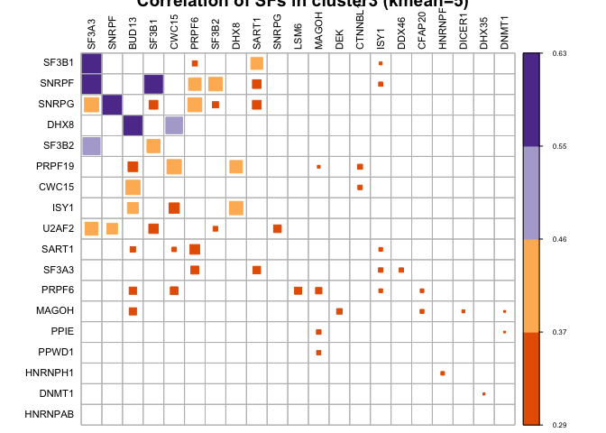

```r
## Interested genes
# extract all names of genes in cluster 3 of kmean = 5
SF_cluster3_k5 = names(which(SFcluster_list[["k5"]]$cluster == 3))

cor_SF_cluster3_k5 = correlation_anno[correlation_anno$so %in% SF_cluster3_k5,]

cor_SF_cluster3_k5 = cor_SF_cluster3_k5 %>%
  left_join(class_df, by = c("so" = "gene")) %>%
  filter(tg %in% names(which(SFcluster_list[["k5"]]$cluster == 3)))

cor_SF_cluster3_k5_mat = cor_SF_cluster3_k5 %>%
  dplyr::select(so, tg, cor) %>%
  pivot_wider(names_from = tg, values_from = cor, values_fill = NA) %>%
  column_to_rownames("so") %>%
  as.matrix()

corrplot(cor_SF_cluster3_k5_mat,
         method = 'square',
         col = brewer.pal(n = 4, name = "PuOr"),
         is.corr = FALSE, # input matrix is non-correlation matrix
         cl.cex = 0.5,
         tl.cex = 0.7,
         tl.col = "black",
         na.label = " ",
         title = "Correlation of SFs in cluster3 (kmean=5)")
```

Cluster 3 was selected for correlation analysis between splicing factors because it shows a distinct: a pattern of high expression (red) at U2AF1, mild/neutral at SF1, and strongly downregulated upon U2AF2 knockdown. This suggests potential positive regulation by U2AF2. In contrast, SF1 knockdown appears to have a minimal effect or distinct pattern on the same gene set, indicating that these splicing factors may be specifically regulated by U2AF2, not SF1. This suggests some genes are oppositely regulated by U2AF1 and U2AF2, possibly due to their functional differences.

**kmean = 5, Cluster = 5**

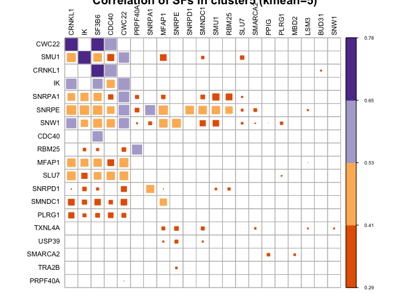

```r
SF_cluster5_k5 = names(which(SFcluster_list[["k5"]]$cluster == 5))

cor_SF_cluster5_k5 = correlation_anno[correlation_anno$so %in% SF_cluster5_k5,]

cor_SF_cluster5_k5 = cor_SF_cluster5_k5 %>%
  left_join(class_df, by = c("so" = "gene")) %>%
  filter(tg %in% names(which(SFcluster_list[["k5"]]$cluster == 5)))

cor_SF_cluster5_k5_mat = cor_SF_cluster5_k5 %>%
  dplyr::select(so, tg, cor) %>%
  pivot_wider(names_from = tg, values_from = cor, values_fill = NA) %>%
  column_to_rownames("so") %>%
  as.matrix()

corrplot(cor_SF_cluster5_k5_mat, method = 'square',
         col = brewer.pal(n = 4, name = "PuOr"),
         is.corr = FALSE,
         cl.cex = 0.5,
         tl.cex = 0.7,
         tl.col = "black",
         na.label = " ",
         title = "Correlation of SFs in cluster5 (kmean=5)")
```

# 6 Pearson correlation heatmap of individual SFs

Task: Make a correlation heatmap of individual SFs, and then use class annotations (like SM proteins, U2 snRNA-related, etc.) to visually interpret or annotate the patterns.

to compare how co-expression patterns (correlation between splicing factor genes) change across different knockdowns (U2AF1, U2AF2, SF1), using log2FC or normalized gene expression values.

[figure not shown]

```r
# Define source genes
source_genes <- c("U2AF1", "U2AF2", "SF1")

# Filter for target genes (your splicing factor list from SF_hm_df)
target_genes <- bind_rows(list(cor_SF_cluster3_k5, cor_SF_cluster5_k5))$so

# Extract expression matrices
SF_source_mat <- SF_hm_mat[rownames(SF_hm_mat) %in% source_genes, ]
SF_target_mat <- SF_hm_mat[rownames(SF_hm_mat) %in% target_genes, ]

# Compute Pearson correlation: each target SF vs. U2AF1/2, SF1
cor_mat <- cor(t(SF_target_mat), t(SF_source_mat), method = "pearson")

# Row clustering
row_dist <- dist(cor_mat)
row_clust <- hclust(row_dist, method = "ward.D2")
row_order <- row_clust$order
cor_mat <- cor_mat[row_order, ]

# ======= Build Functional Class Annotation =======

# Map splice_SYMBOL → class
class_map <- setNames(as_anno$class, as_anno$splice_SYMBOL)

# Match classes for genes in the correlation matrix
class_vector <- class_map[rownames(cor_mat)]

# Filter NA (if any)
cor_mat <- cor_mat[!is.na(class_vector), ]
class_vector <- class_vector[!is.na(class_vector)]

# Merge detailed class → broader categories
#class_merge_map <- c(
#  "U1 snRNP" = "Spliceosome",
#  "U2 snRNP" = "Spliceosome",
#  "U2 snRNP related" = "Spliceosome",
#  "U4/U6 snRNP" = "Spliceosome",
#  "U4/U6.U5 snRNP" = "Spliceosome",
#  "U5 snRNP" = "Spliceosome",
#  "A complex" = "Spliceosome",
#  "B complex" = "Spliceosome",
#  "C complex" = "Spliceosome",
#  "PRP19 complex" = "Spliceosome",
#  "Bact complex" = "Spliceosome",
#  "SM proteins" = "Spliceosome",

# "RNA binding proteins" = "RNA metabolism",
#  "RNA modifying" = "RNA metabolism",
#  "RNA degradation" = "RNA metabolism",
#  "RNA metylation" = "RNA metabolism",
#  "RNA editing" = "RNA metabolism",

#  "SR proteins" = "Regulators",
#  "hnRNP" = "Regulators",
#  "3´end" = "Regulators",
#  "TREX" = "Regulators",
#  "EJC / mRNP" = "Regulators",
#  "CBC" = "Regulators",

#  "SWI/SNF Complex Components" = "Other functions",
# "chromatin-related" = "Other functions",
#  "Polycomb Group Genes" = "Other functions",
#  "Histone transferases" = "Other functions",
# "Lysine transferases" = "Other functions",
#  "helicase" = "Other functions",
#  "protein kinase" = "Other functions",
#  "LSm proteins" = "Other functions",
#  "RES complex" = "Other functions",
#  "Minor" = "Other functions",
#  "Other SAPs" = "Other functions",
#  "RISC" = "Other functions")

#merged_class_vector <- class_merge_map[class_vector]
#merged_class_vector[is.na(merged_class_vector)] <- "Others"

# Build row annotation
#manual_colors <- c(
#  "Spliceosome" = "#FF9900FF",
#  "RNA metabolism" = "yellow",
#  "Regulators" = "#33FF33FF",
#  "Other functions" = "#264EFFFF",
#  "Others" = "black")

# Get unique class names
class_names <- sort(unique(class_vector))  # should be 35

# Generate 35 distinct colors
palette_color <- createPalette(length(class_names), seedcolors = c("#E41A1C", "#377EB8", "#4DAF4A"))

# Assign colors
manual_colors <- setNames(palette_color, class_names)

# Build color list for annotation
class_colors <- list(Class = manual_colors)

# Create row annotation
ha_row <- rowAnnotation(
  Class = class_vector,
  col = class_colors,
  width = unit(25, "mm"),
  show_legend = TRUE,
  annotation_name_gp = gpar(fontsize = 10, fontface = "bold", col = "darkred")
)

# Side (row) annotation

# ======= Correlation Heatmap =======
Heatmap(
  cor_mat,
  cluster_columns = FALSE,
  cluster_rows = FALSE,
  show_row_names = TRUE,
  row_names_gp = gpar(fontsize = 6),
  col = colorRamp2(c(-1, 0, 1), c("blue", "white", "red")),
#  row_split = class_vector,  # SPLIT BY FUNCTIONAL CLASS
  name = "Pearson\ncorrelation",
  row_title = "Splicing Factors",
  column_title = "Correlation with\nU2AF1 / U2AF2 / SF1",
  column_title_gp = gpar(fontsize = 12, fontface = "bold"),
  row_title_gp = gpar(fontsize = 12, fontface = "bold"),
  heatmap_width = unit(10, "cm"),
  heatmap_height = unit(20, "cm"),
  right_annotation = ha_row,
  border = TRUE
)
```

## 6.1 gProfiler result

### 6.1.1 U2AF2 unique regulated genes

Insert data from g:Profiler: A REAC g:Profiler result indicates that the analysis has identified statistically significant enrichment of Reactome pathways within a given gene list.

https://biit.cs.ut.ee/gplink/l/avHqC_JRaSe

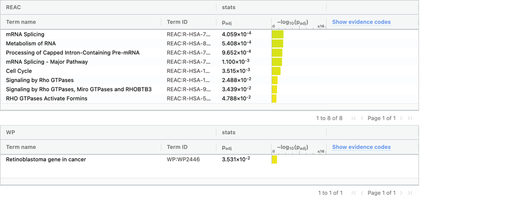

```r
gpro_uniq_reg_U2AF2_png = image_read("/Users/tinkienoob/Master_thesis/HepG2_DESeq_analysis/gProfiler_reac_wp_uniq_reg_U2AF2KD.png")
print(gpro_uniq_reg_U2AF2_png, info = FALSE)
```

```r
gpro_uniq_reg_U2AF2 = read_csv("/Users/tinkienoob/Master_thesis/HepG2_DESeq_analysis/gProfiler_reac_wp_uniq_reg_U2AF2KD.csv") %>%
  as.data.frame()

# Split into a vector of genes (since it's often a comma-separated string):
gpro_intersections_U2AF2uniq = lapply(gpro_uniq_reg_U2AF2$intersections, function(x) {
  trimws(strsplit(x, ",")[[1]])
})

# Extract only Rentinoblastoma genes in cancer
wp_uniq_reg_U2AF2 = gpro_uniq_reg_U2AF2 %>%
  filter(term_name %in% c("Retinoblastoma gene in cancer"))

# Split into a vector of genes (since it's often a comma-separated string):
wp_uniq_reg_U2AF2_genes = strsplit(wp_uniq_reg_U2AF2$intersections, ",")[[1]]

# Extract those genes in dataset
wp_uniq_reg_U2AF2_df = res_U2AF2.df[res_U2AF2.df$GeneID %in% wp_uniq_reg_U2AF2_genes,]
```

Check whether downregulation is direct or indirect. Are any of these genes: Direct targets of U2AF2? Known to be alternatively spliced? MAJIQ or eCLIP data for U2AF2 (visualize bigWig files on IGV to find splice junction)

```r
x = enrichGO(gene = wp_uniq_reg_U2AF2_df$GeneID,
                OrgDb = org.Hs.eg.db,
                keyType = "ENSEMBL",
                ont = "BP",
                pAdjustMethod = "BH",
                readable = TRUE)

as.data.frame(x)
```

[output not shown]

[output cut: 265 more lines]

```
GO:0034644                                    CDC25A/PCNA     2
GO:0072332                                      E2F2/E2F1     2
GO:0009416                               MSH6/CDC25A/PCNA     3
GO:1903312                                     BARD1/E2F1     2
GO:0071214                              CDC25A/PCNA/BARD1     3
GO:0104004                              CDC25A/PCNA/BARD1     3
GO:0010948                              CDKN1B/BARD1/E2F1     3
GO:2000278                                      RFC5/PCNA     2
GO:0006310                                CDC7/MSH6/BARD1     3
GO:0097193                                 MSH6/E2F2/E2F1     3
GO:0045787                              CCND3/CDC7/CDC25A     3
GO:0032355                                    CDKN1B/PCNA     2
GO:0008630                                      MSH6/E2F1     2
GO:0071482                                    CDC25A/PCNA     2
GO:0043200                                    CDKN1B/PCNA     2
```

- Load significant junction changing results

```r
outpath = "/Users/tinkienoob/Master_thesis/Functional splice factor analysis/"
U2AF2_highest_junction = readRDS(paste0(outpath, "U2AF2_highest_junction.rds"))
U2AF1_highest_junction = readRDS(paste0(outpath, "U2AF1_highest_junction.rds"))
SF1_highest_junction = readRDS(paste0(outpath, "SF1_highest_junction.rds"))
```

Scatter plot compares log2FoldChange (U2AF2 KD vs control) with ΔPSI (junction changing) for Retinoblastoma pathway genes regulated by U2AF2 SFs.

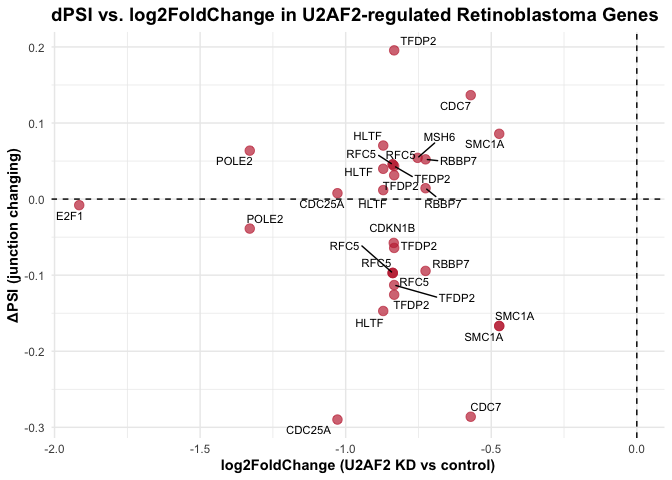

```r
# Filter only the genes of interest from sig_junctionchange
U2AF2_highest_junction$GeneID = gsub("\\..*", "", U2AF2_highest_junction$module_id)

wp_U2AF2_uniq_high_junc_genes = U2AF2_highest_junction %>%
  filter(GeneID %in% wp_uniq_reg_U2AF2_genes)

# Merge dPSI and L2FC
wp_U2AF2_uniq_high_junc_df = wp_U2AF2_uniq_high_junc_genes %>%
  left_join(res_U2AF2.df, by = "GeneID") %>%
  dplyr::select(c("GeneID", "dpsi", "class", "log2FoldChange", "gene_name", "padj"))

ggplot(wp_U2AF2_uniq_high_junc_df, aes(x = log2FoldChange, y = dpsi)) +
  geom_point(color = "#C43142", size = 3, alpha = 0.7) +
  geom_text_repel(aes(label = gene_name), size = 3, max.overlaps = 30) +
  theme_minimal() +
  labs(
    title = "dPSI vs. log2FoldChange in U2AF2-regulated Retinoblastoma Genes",
    x = "log2FoldChange (U2AF2 KD vs control)",
    y = "ΔPSI (junction changing)"
  ) +
  geom_hline(yintercept = 0, linetype = "dashed") +
  geom_vline(xintercept = 0, linetype = "dashed") +
  theme(
    plot.title = element_text(face = "bold", size = 14),
    axis.title = element_text(face = "bold")
  )
```